# k-Nearest Neighbours Practical

## Blood Brain Barrier (Regression)

We want to test whether removing the ‘outlier’ points in the test set improves the correlation between predicted and observed values. To do this, we prepare the dataset exactly as before and train a kNN.

```r
# Load dataset
library(caret)
data(BloodBrain)
str(bbbDescr)
```

```
## 'data.frame':    208 obs. of  134 variables:
##  $ tpsa                : num  12 49.3 50.5 37.4 37.4 ...
##  $ nbasic              : int  1 0 1 0 1 1 1 1 1 1 ...
##  $ negative            : int  0 0 0 0 0 0 0 0 0 0 ...
##  $ vsa_hyd             : num  167.1 92.6 295.2 319.1 299.7 ...
##  $ a_aro               : int  0 6 15 15 12 11 6 12 12 6 ...
##  $ weight              : num  156 151 366 383 326 ...
##  $ peoe_vsa.0          : num  76.9 38.2 58.1 62.2 74.8 ...
##  $ peoe_vsa.1          : num  43.4 25.5 124.7 124.7 118 ...
##  $ peoe_vsa.2          : num  0 0 21.7 13.2 33 ...
##  $ peoe_vsa.3          : num  0 8.62 8.62 21.79 0 ...
##  $ peoe_vsa.4          : num  0 23.3 17.4 0 0 ...
##  $ peoe_vsa.5          : num  0 0 0 0 0 0 0 0 0 0 ...
##  $ peoe_vsa.6          : num  17.24 0 8.62 8.62 8.62 ...
##  $ peoe_vsa.0.1        : num  18.7 49 83.8 83.8 83.8 ...
```

[output cut: 86 more lines]

```r
str(logBBB)
```

```
##  num [1:208] 1.08 -0.4 0.22 0.14 0.69 0.44 -0.43 1.38 0.75 0.88 ...
```

```r
set.seed(42)

# Split into training and test
trainIndex <- createDataPartition(y=logBBB, times=1, p=0.8, list=F)
descrTrain <- bbbDescr[trainIndex,]
concRatioTrain <- logBBB[trainIndex]
descrTest <- bbbDescr[-trainIndex,]
concRatioTest <- logBBB[-trainIndex]

# Preprocess
transformations <- preProcess(descrTrain,
                              method=c("center", "scale", "corr", "nzv"),
                              cutoff=0.75)
descrTrain <- predict(transformations, descrTrain)

# Set up seeds
set.seed(42)
seeds <- vector(mode = "list", length = 26)
for(i in 1:25) seeds[[i]] <- sample.int(1000, 10)
seeds[[26]] <- sample.int(1000,1)

# Train kNN
knnTune <- train(descrTrain,
                 concRatioTrain,
                 method="knn",
                 tuneGrid = data.frame(.k=1:10),
                 trControl = trainControl(method="repeatedcv",
                                          number = 5,
                                          repeats = 5,
                                          seeds=seeds,
                                          preProcOptions=list(cutoff=0.75))
                 )

knnTune
```

```
## k-Nearest Neighbors
##
## 168 samples
##  63 predictor
##
## No pre-processing
## Resampling: Cross-Validated (5 fold, repeated 5 times)
## Summary of sample sizes: 136, 133, 134, 134, 135, 135, ...
## Resampling results across tuning parameters:
##
##   k   RMSE       Rsquared   MAE
##    1  0.6572204  0.4094071  0.4739994
##    2  0.5838867  0.4737129  0.4319682
##    3  0.5869985  0.4632044  0.4377774
##    4  0.6023137  0.4313942  0.4554854
##    5  0.6119249  0.4130384  0.4653676
##    6  0.6134509  0.4086748  0.4710572
##    7  0.6289054  0.3803895  0.4846857
##    8  0.6331586  0.3748235  0.4843006
##    9  0.6358699  0.3744272  0.4835743
##   10  0.6321851  0.3859343  0.4805353
##
## RMSE was used to select the optimal model using the smallest value.
## The final value used for the model was k = 2.
```

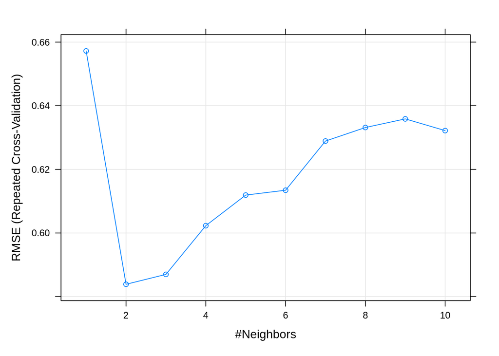

```r
plot(knnTune)
```

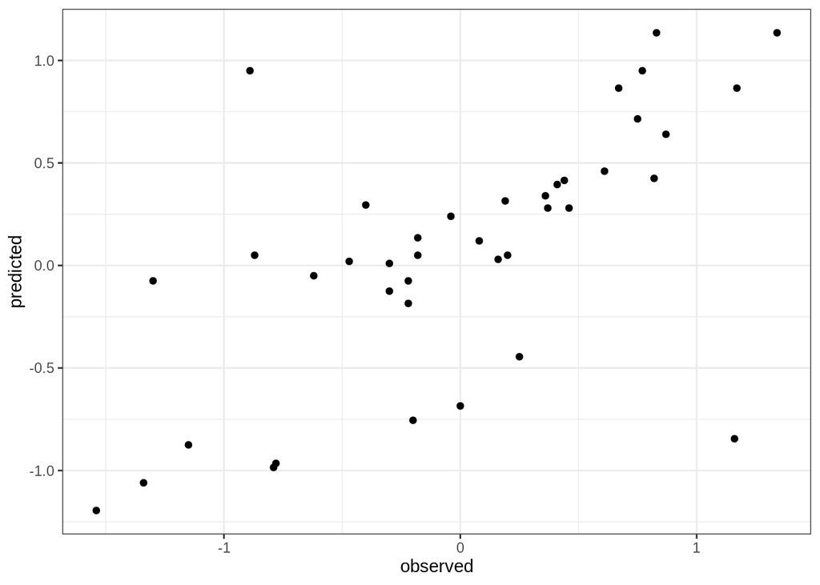

```r
# Use kNN to predict on test set
descrTest <- predict(transformations, descrTest)
test_pred <- predict(knnTune, descrTest)

# Scatter plot comparing test observed and predicted values
qplot(concRatioTest, test_pred) +
  xlab("observed") +
  ylab("predicted") +
  theme_bw()
```

```r
# Calculate correlation between predicted and observed values
cor(concRatioTest, test_pred)
```

```
## [1] 0.6386877
```

We can also do the same for the training data and see quite high correlation between predicted and observed:

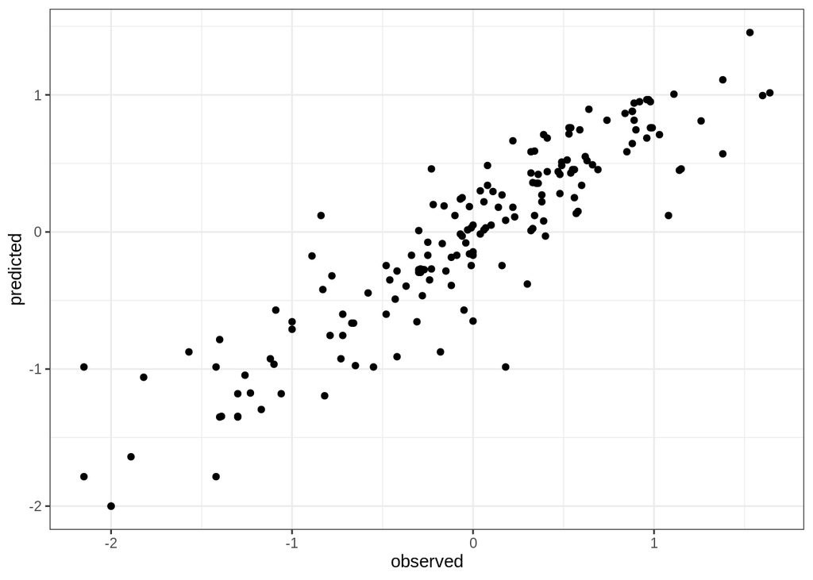

```r
train_pred <- predict(knnTune, descrTrain)

# Scatter plot comparing training observed and predicted values
qplot(concRatioTrain, train_pred) +
  xlab("observed") +
  ylab("predicted") +
  theme_bw()
```

```r
# Calculate correlation between predicted and observed values
cor(concRatioTrain, train_pred)
```

```
## [1] 0.9117623
```

To identify which points to remove, we could use a number of techniques for outlier selection. For simplicity here, we will just remove the points where the predicted and observed and more than 1 away from each other, which is quite a conservative approach. To visualise which points we will remove, we plot y=x+1 and y=x-1.

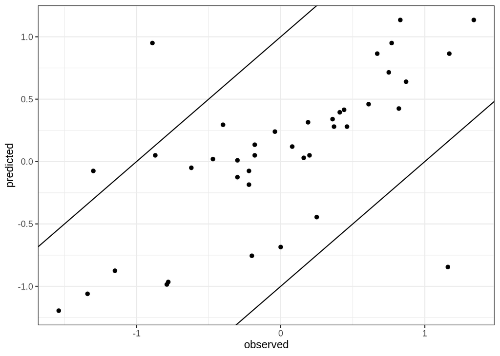

```r
qplot(concRatioTest, test_pred) +
  xlab("observed") +
  ylab("predicted") +
  theme_bw() +
  geom_abline(slope=1,intercept=1) +
  geom_abline(slope=1,intercept=-1)
```

We then identify those points and replot:

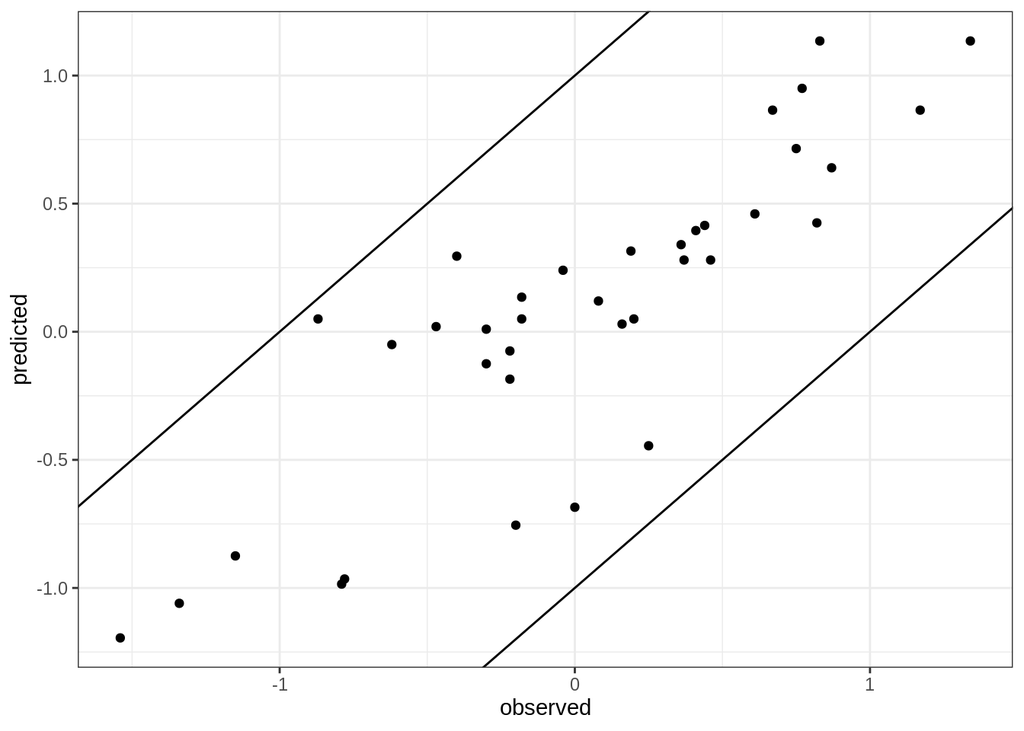

```r
outliers = concRatioTest>(test_pred+1) | concRatioTest<(test_pred-1)
qplot(concRatioTest[!outliers], test_pred[!outliers]) +
  xlab("observed") +
  ylab("predicted") +
  theme_bw() +
  geom_abline(slope=1,intercept=1) +
  geom_abline(slope=1,intercept=-1)
```

Now we recalculate the correlation:

```r
cor(concRatioTest[!outliers], test_pred[!outliers])
```

```
## [1] 0.8592044
```

We see that the value is much higher, even from removing very few points.

## Cell segmentation

In the cell segmentation data, we want to understand whether subsampling the larger class (PS) would help the model perform better. We start off by loading the data and splitting into training and test exactly as before.

```r
data(segmentationData)
str(segmentationData)
```

```
## 'data.frame':    2019 obs. of  61 variables:
##  $ Cell                   : int  207827637 207932307 207932463 207932470 207932455 207827656 207827659 207827661 207932479 207932480 ...
##  $ Case                   : Factor w/ 2 levels "Test","Train": 1 2 2 2 1 1 1 1 1 1 ...
##  $ Class                  : Factor w/ 2 levels "PS","WS": 1 1 2 1 1 2 2 1 2 2 ...
##  $ AngleCh1               : num  143.25 133.75 106.65 69.15 2.89 ...
##  $ AreaCh1                : int  185 819 431 298 285 172 177 251 495 384 ...
##  $ AvgIntenCh1            : num  15.7 31.9 28 19.5 24.3 ...
##  $ AvgIntenCh2            : num  4.95 206.88 116.32 102.29 112.42 ...
##  $ AvgIntenCh3            : num  9.55 69.92 63.94 28.22 20.47 ...
##  $ AvgIntenCh4            : num  2.21 164.15 106.7 31.03 40.58 ...
##  $ ConvexHullAreaRatioCh1 : num  1.12 1.26 1.05 1.2 1.11 ...
##  $ ConvexHullPerimRatioCh1: num  0.92 0.797 0.935 0.866 0.957 ...
##  $ DiffIntenDensityCh1    : num  29.5 31.9 32.5 26.7 31.6 ...
##  $ DiffIntenDensityCh3    : num  13.8 43.1 36 22.9 21.7 ...
##  $ DiffIntenDensityCh4    : num  6.83 79.31 51.36 26.39 25.03 ...
```

[output cut: 47 more lines]

```r
segClass <- segmentationData$Class
segData <- segmentationData[,4:59]
set.seed(42)
trainIndex <- createDataPartition(y=segClass, times=1, p=0.5, list=F)
segDataTrain <- segData[trainIndex,]
segDataTest <- segData[-trainIndex,]
segClassTrain <- segClass[trainIndex]
segClassTest <- segClass[-trainIndex]
summary(segClassTrain)
```

```
##  PS  WS
## 650 360
```

```r
summary(segClassTest)
```

```
##  PS  WS
## 650 359
```

We then need to down-sample the larger class:

```r
set.seed(42)
segSub <- downSample(segDataTrain, segClassTrain, list = FALSE, yname = "Class")
segDataTrainSub <- segSub[,1:(ncol(segSub)-1)]
segClassTrainSub <- segSub$Class
```

After that, we train the model exactly as before:

```r
set.seed(42)
seeds <- vector(mode = "list", length = 26)
for(i in 1:25) seeds[[i]] <- sample.int(1000, 50)
seeds[[26]] <- sample.int(1000,1)
train_ctrl <- trainControl(method="repeatedcv",
                   number = 5,
                   repeats = 5,
                   #preProcOptions=list(cutoff=0.75),
                   seeds = seeds)
tuneParam <- data.frame(k=seq(5,500,10))
transformations <- preProcess(segDataTrainSub,
                              method=c("YeoJohnson", "center", "scale", "corr"),
                              cutoff=0.75)
segDataTrainSub <- predict(transformations, segDataTrainSub)
str(segDataTrainSub)
```

```
## 'data.frame':    720 obs. of  24 variables:
##  $ AngleCh1               : num  -1.242 -0.155 -0.889 0.439 -1.059 ...
##  $ ConvexHullPerimRatioCh1: num  0.761 -0.473 -0.535 1.1 -0.4 ...
##  $ EntropyIntenCh1        : num  0.514 -1.114 -1.196 0.711 1.144 ...
##  $ EqSphereVolCh1         : num  0.47 -1.225 -0.267 -0.57 1.115 ...
##  $ FiberAlign2Ch3         : num  -1.7281 1.806 0.4149 -0.0242 -0.0324 ...
##  $ FiberAlign2Ch4         : num  -1.74 1.85 1.033 1.375 -0.885 ...
##  $ FiberWidthCh1          : num  0.834 -1.776 -0.822 0.829 -0.699 ...
##  $ IntenCoocASMCh3        : num  -0.6814 -0.6589 -0.4317 -0.0875 0.0845 ...
##  $ IntenCoocASMCh4        : num  -0.351 4.104 -0.438 -0.653 -0.349 ...
##  $ IntenCoocContrastCh3   : num  2.967 1.325 -0.222 -0.542 0.21 ...
##  $ IntenCoocContrastCh4   : num  0.922 -2.421 -0.126 1.007 -0.359 ...
##  $ KurtIntenCh1           : num  -1.014 0.353 0.356 -1.171 -0.748 ...
##  $ KurtIntenCh3           : num  -1.119 -0.606 -1.883 0.643 0.145 ...
##  $ KurtIntenCh4           : num  0.6765 1.793 0.1242 -0.6192 -0.0263 ...
##  $ NeighborMinDistCh1     : num  0.185 -0.552 -1.098 -1.145 -1.112 ...
##  $ NeighborVarDistCh1     : num  1.373 0.698 0.173 -1.57 0.737 ...
##  $ ShapeBFRCh1            : num  0.215 -1.713 -1.153 0.761 -1.427 ...
##  $ ShapeLWRCh1            : num  0.0889 1.2364 -0.0567 -1.3718 1.2469 ...
##  $ SpotFiberCountCh3      : num  -1.639 -0.441 0.315 -0.441 0.878 ...
##  $ SpotFiberCountCh4      : num  0.0948 -2.1498 -0.7422 -0.2803 0.6772 ...
##  $ TotalIntenCh1          : num  0.5 -1.469 -1.309 0.857 0.818 ...
##  $ TotalIntenCh2          : num  -1.339 -1.85 -0.674 0.413 0.299 ...
##  $ VarIntenCh3            : num  -1.924 -0.277 -0.64 -0.131 -1.563 ...
##  $ VarIntenCh4            : num  -2.308 -1.5026 0.4327 -0.0112 0.9643 ...
```

```r
knnFit <- train(segDataTrainSub, segClassTrainSub,
                method="knn",
                tuneGrid=tuneParam,
                trControl=train_ctrl)
knnFit
```

```
## k-Nearest Neighbors
##
## 720 samples
##  24 predictor
##   2 classes: 'PS', 'WS'
##
## No pre-processing
## Resampling: Cross-Validated (5 fold, repeated 5 times)
## Summary of sample sizes: 576, 576, 576, 576, 576, 576, ...
## Resampling results across tuning parameters:
##
##   k    Accuracy   Kappa
##     5  0.7652778  0.5305556
##    15  0.8011111  0.6022222
##    25  0.8002778  0.6005556
```

[output cut: 50 more lines]

We can look at the performance on the training and test sets after subsampling:

```r
train_pred <- predict(knnFit, segDataTrainSub)
confusionMatrix(train_pred, segClassTrainSub)
```

```
## Confusion Matrix and Statistics
##
##           Reference
## Prediction  PS  WS
##         PS 260  40
##         WS 100 320
##
##                Accuracy : 0.8056
##                  95% CI : (0.7747, 0.8339)
##     No Information Rate : 0.5
##     P-Value [Acc > NIR] : < 2.2e-16
##
##                   Kappa : 0.6111
##
##  Mcnemar's Test P-Value : 6.151e-07
##
##             Sensitivity : 0.7222
##             Specificity : 0.8889
##          Pos Pred Value : 0.8667
##          Neg Pred Value : 0.7619
##              Prevalence : 0.5000
##          Detection Rate : 0.3611
##    Detection Prevalence : 0.4167
##       Balanced Accuracy : 0.8056
##
##        'Positive' Class : PS
##
```

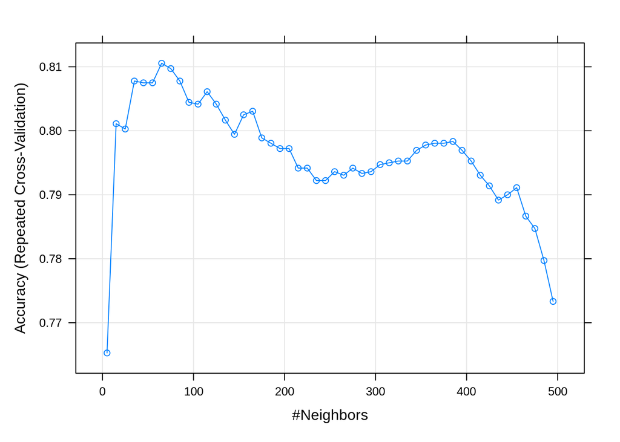

```r
plot(knnFit)
```

```r
segDataTestPrep <- predict(transformations, segDataTest)
test_pred <- predict(knnFit, segDataTestPrep)
confusionMatrix(test_pred, segClassTest)
```

```
## Confusion Matrix and Statistics
##
##           Reference
## Prediction  PS  WS
##         PS 462  32
##         WS 188 327
##
##                Accuracy : 0.782
##                  95% CI : (0.7552, 0.8071)
##     No Information Rate : 0.6442
##     P-Value [Acc > NIR] : < 2.2e-16
##
##                   Kappa : 0.5665
##
##  Mcnemar's Test P-Value : < 2.2e-16
##
##             Sensitivity : 0.7108
##             Specificity : 0.9109
##          Pos Pred Value : 0.9352
##          Neg Pred Value : 0.6350
##              Prevalence : 0.6442
##          Detection Rate : 0.4579
##    Detection Prevalence : 0.4896
##       Balanced Accuracy : 0.8108
##
##        'Positive' Class : PS
##
```

After we perform the subsampling, we actually now get better performance on the WS set compared to the PS set.